# Predicting Chartbusters using ML Techniques (Title WIP)

For many full-time music artists, getting high chart positions is their meal ticket; they need to have a prominent presence in the industry in order to make money and chart positions are a clear way of showing just how prominent they are. At the end of each year, Spotify compiles a playlist of the songs streamed most often over the course of that year. This year’s playlist included 100 songs. The question is: What do these top songs have in common? Why do people like them?

## Introduction

Music, as one can claim, is a art-form composed and performed for many purposes ranging from aesthetic pleasure, ceremonial purposes, or to an entertainment product used for mass comsumption. Prior to the invention of sound recordings, people would actually buy sheet music and play at home on a piano for enjoyment. Now in modern times, music can be easily enjoyed through online streaming services such as Spotify, Apple Music, YouTube Music, and Pandora etc.

With that being said, a song's popularity can be measured by its chart position. For many musicians, getting their songs to chart high is of paramount importance in order garner a prominent presense in the music industry, and above all, to make money.

So now we ask: What do all these hit songs have in common? Is there a certain pattern or characteristics to determine a hit song? What are the significant and influential predictors?

## Data Summary & Description

We acquired data using Spotify's API for songs released in 2017. With Spotify's acquisition of Echo Nest, a music intelligence and data platform, their API allows users to access a song's audio features. These features includes attributes such as a song's level of acousticess, loudness, tempo and energy etc.

We pulled a total number of 7429 records, each categorized by 10 features.

Below is a detailed description of each of the features we used:

| Features | Description |
| --- | --- |
| acousticness | A confidence measure from 0.0 to 1.0 of whether the track is acoustic. 1.0 represents high confidence the track is acoustic. |
| danceability | Danceability describes how suitable a track is for dancing based on a combination of musical elements including tempo, rhythm stability, beat strength, and overall regularity. A value of 0.0 is least … |
| duration_ms | The duration of the track in milliseconds. |
| energy | Energy is a measure from 0.0 to 1.0 and represents a perceptual measure of intensity and activity. Typically, energetic tracks feel fast, loud, and noisy. For example, death metal has high energy, whi… |
| instrumentalness | Predicts whether a track contains no vocals. “Ooh” and “aah” sounds are treated as instrumental in this context. Rap or spoken word tracks are clearly “vocal”. The closer the instrumentalness value is… |
| liveness | Detects the presence of an audience in the recording. Higher liveness values represent an increased probability that the track was performed live. A value above 0.8 provides strong likelihood that the… |
| loudness | The overall loudness of a track in decibels (dB). Loudness values are averaged across the entire track and are useful for comparing relative loudness of tracks. Loudness is the quality of a sound that… |
| speechiness | Speechiness detects the presence of spoken words in a track. The more exclusively speech-like the recording (e.g. talk show, audio book, poetry), the closer to 1.0 the attribute value. Values above 0.… |
| tempo | The overall estimated tempo of a track in beats per minute (BPM). In musical terminology, tempo is the speed or pace of a given piece and derives directly from the average beat duration. |
| valence | A measure from 0.0 to 1.0 describing the musical positiveness conveyed by a track. Tracks with high valence sound more positive (e.g. happy, cheerful, euphoric), while tracks with low valence sound mo… |
| artist_popularity | The popularity of the artist. The value will be between 0 and 100, with 100 being the most popular. The artist’s popularity is calculated from the popularity of all the artist’s tracks. |

Using this data, we mapped each song to whether or not it was a hit if it satisfies either of these rules:

- The song was in the Spotify's Top Tracks of 2017 playlist.
- The song was in the Spotify's Top Artists of 2017 playlist.
- The song was in the Top tracks of 2017: USA playlist.
- The song charted at least once in the Billboard's Hot-100 playlist throughout 2017.

#### Data Acquisition

Python was used to pull data from Spotify's API, primarily utilizing a package called Spotipy (https://github.com/plamere/spotipy). Spotipy is a thin client library that handles the OAuth authorization flow (using a client id and client secret one needs to provide after signing up for a web developer account at Spotify) and access to all of the music data provided in JSON format.

Here's a code snippet for getting all the songs released in 2017 in the US:

```python
def get_songs_by_year_released(client: spotipy.Spotify, year: int) -> pd.DataFrame:
    ''' returns a pandas dataframe of songs of given year

        Parameters:
            - client: spotipy wrapper client
            - year: the year in which songs were released
    '''
    result = []
    id_set = set()
    for i in range(200):
        search_results = client.search(q="year:{}".format(year), type="track", market="US", limit=50, offset=50*i)
        for item in search_results.get("tracks").get("items"):
            artist = item.get("artists")[0]
            artist_name = artist.get("name")
            artist_id = artist.get("id")
            artist_popularity = client.artist(artist_id).get("popularity")
            track = item.get("name")
            track_id = item.get("id")
            if track_id not in id_set:
                t = {"aid": artist_id, "artist": artist_name, "artist_popularity": artist_popularity, "track": track, "id": track_id}
                result.append(t)
                id_set.add(track_id)
    return pd.DataFrame(result)
```

Spotify's search endpoint that allows users to get Spotify Catalog information about artists, albums, tracks or playlists which match a keyword string only allows 50 results per query. Hence, I had to provide an offset value for every query, making a total number of 200 requests. This was primarily intended to get 10000 records, however there were duplicate songs provided in each result set, decreasing the number down to 7429.

Then, using the songs we pulled, we marked each of them with their corresponding song attributes:

```python
def get_songs_features(client: spotipy.Spotify, df: pd.DataFrame) -> pd.DataFrame:
    ''' returns a pandas dataframe of song features of given songs

        Parameters:
            - client: spotipy wrapper client
            - df: pandas dataframe of songs from get_songs_by_year_released
    '''
    result = []
    songs_id = df["id"]
    for i in range(200):
        features = client.audio_features(songs_id[50*i:50*(i+1)])
        for s in features:
            if s is not None:
                result.append(s)
    features = pd.DataFrame(result)
    return pd.merge(features, df, on='id')
```

Next, we marked each record indicating whether or not they were a hit. Here, we also used another python package called billboard.py (https://github.com/guoguo12/billboard-charts) which allows accessing music charts from Billboard.com.

```python
def get_top_tracks_of_2017(client: spotipy.Spotify, df: pd.DataFrame, playlist_ids: str) -> pd.DataFrame:
    ''' returns an updated pandas dataframe of song features with a new hit value:
        0 - not in the given top playlist
        1 - in the given top playlist

        Parameters:
            - client: spotipy wrapper client
            - df: pandas dataframe of song features from get_songs_features
            - playlist_ids: list of public playlist ids of the top songs
    '''
    df["hit"] = 0

    ## First query the Spotify public playlists
    result = set()
    for pid in playlist_ids:
        uri = "spotify:user:spotifycharts:playlist:{}".format(pid)
        username = uri.split(':')[2]
        playlist_id = uri.split(':')[4]
        playlist_results = client.user_playlist(username, playlist_id)
        hit_songs = set([item.get("track").get("id") for item in playlist_results.get("tracks").get("items")])
        result = result.union(hit_songs)
    df.loc[df["id"].isin(hit_songs), "hit"] = 1

    ## Second, query the Billboard data
    date_template = "2017-{:02d}-01"
    songs = set()
    for i in range(1, 13):
        print(date_template.format(i))
        chart = billboard.ChartData('hot-100', date = date_template.format(i))
        to_add = set([c.title for c in chart])
        songs = songs.union(to_add)
    df.loc[df["track"].isin(songs), "hit"] = 1
    return df
```

Here is the resulting data set after we've selected the columns we needed, and filtering out records that weren't songs (i.e. records on Spotify that are sleep sounds, white noise, instrumental music with no vocals).

```python
data = pd.read_csv("song_features_2017.csv")
data.drop(data.loc[data["tempo"] == 0, "track"].index, inplace = True)
data.drop(data.loc[data["speechiness"] >= 0.66, "track"].index, inplace = True)
data.drop(data.loc[data["liveness"] >= 0.8, "track"].index, inplace = True)
data.drop(data.loc[data["instrumentalness"] >= 0.8, "track"].index, inplace = True)
df = data[["acousticness", "danceability", "duration_ms", "energy", "instrumentalness", "liveness", "loudness", "speechiness", "tempo", "valence", "artist_popularity", "hit"]]
df.head(10)
```

|  | acousticness | danceability | duration_ms | energy | instrumentalness | liveness | loudness | speechiness | tempo | valence | artist_popularity | hit |
| --- | --- | --- | --- | --- | --- | --- | --- | --- | --- | --- | --- | --- |
| 0 | 0.469000 | 0.872 | 119133 | 0.391 | 0.000004 | 0.2970 | -9.144 | 0.2420 | 134.021 | 0.437 | 98 | 1 |
| 1 | 0.017200 | 0.797 | 146520 | 0.533 | 0.000152 | 0.1030 | -9.740 | 0.0412 | 131.036 | 0.329 | 98 | 0 |
| 2 | 0.847000 | 0.734 | 95467 | 0.570 | 0.000021 | 0.1120 | -7.066 | 0.1330 | 129.953 | 0.689 | 98 | 1 |
| 3 | 0.737000 | 0.483 | 203569 | 0.412 | 0.000000 | 0.1160 | -8.461 | 0.0402 | 170.163 | 0.247 | 93 | 0 |
| 4 | 0.149000 | 0.880 | 172800 | 0.428 | 0.000051 | 0.1140 | -8.280 | 0.2060 | 100.007 | 0.333 | 91 | 0 |
| 5 | 0.002640 | 0.732 | 182707 | 0.750 | 0.000000 | 0.1090 | -6.366 | 0.2310 | 155.096 | 0.401 | 89 | 1 |
| 6 | 0.138000 | 0.718 | 156000 | 0.767 | 0.000000 | 0.1140 | -5.641 | 0.1660 | 160.084 | 0.519 | 85 | 0 |
| 7 | 0.493000 | 0.763 | 190472 | 0.572 | 0.001180 | 0.1060 | -7.312 | 0.0595 | 151.930 | 0.250 | 73 | 0 |
| 8 | 0.199000 | 0.798 | 202547 | 0.539 | 0.000017 | 0.1650 | -6.351 | 0.0421 | 136.949 | 0.394 | 96 | 1 |
| 9 | 0.000282 | 0.908 | 177000 | 0.621 | 0.000054 | 0.0958 | -6.638 | 0.1020 | 150.011 | 0.421 | 91 | 1 |

## Analysis

Since this is a binary classification problem, we will use the following the methods:

- Logistic Regression
- Gaussian Naive Bayes
- Decision Tree
- Random Forests

And for evaluating the model, we will need to take consideration that our model is has class imbalance: 287 hits and 6358 no-hits.

Hence, we cannot use Accurary as an evaluation measure since our model can simply predict all as no-hits have acheive a 95% accuracy rate.

Thus, we will use the AUC as it is a function of sensitivity and specificity, the curve is insensitive to disparities in the class proportions. Along with other metrics such as F1-score, precision and recall.

### Technique 1: Logistic Regression

First, we separate the data indicating X as the independent variables, and y as the dependent variable.

```python
predictors = ["acousticness", "danceability", "energy", "instrumentalness", "liveness", "loudness", "speechiness", "tempo", "valence", "artist_popularity"]
X = df[predictors]
y = df["hit"].astype("bool")
```

#### Without pre-processing data:

```python
# Split training data and validating data (70-30 split)
x_train, x_test, y_train, y_test = train_test_split(X, y, test_size=0.3)
logisticRegr = LogisticRegression(solver='liblinear', random_state=10)
logisticRegr.fit(x_train, y_train)
y_test_pred = logisticRegr.predict(x_test)
cnf_matrix = metrics.confusion_matrix(y_test, y_test_pred)
print(cnf_matrix)
print(metrics.classification_report(y_test, y_test_pred))
```

```
[[1903    0]
 [  91    0]]
              precision    recall  f1-score   support

       False       0.95      1.00      0.98      1903
        True       0.00      0.00      0.00        91

   micro avg       0.95      0.95      0.95      1994
   macro avg       0.48      0.50      0.49      1994
weighted avg       0.91      0.95      0.93      1994
```

From the results, we can already see that this model is not a good model for prediction as it did not predict any songs to be hits, and pretty much predicted all songs to be non-hits.

If we look at the significance of our model's predictors, we get the following:

```python
logit = sm.Logit(y, X)
logit.fit().summary()
```

```
Optimization terminated successfully.
         Current function value: 0.163836
         Iterations 10
```

Logit Regression Results

| Dep. Variable: | hit | No. Observations: | 6645 |
| --- | --- | --- | --- |
| Model: | Logit | Df Residuals: | 6635 |
| Method: | MLE | Df Model: | 9 |
| Date: | Sat, 01 Dec 2018 | Pseudo R-squ.: | 0.07933 |
| Time: | 21:18:27 | Log-Likelihood: | -1088.7 |
| converged: | True | LL-Null: | -1182.5 |
|  |  | LLR p-value: | 1.291e-35 |

|  | coef | std err | z | P>\|z\| | [0.025 | 0.975] |
| --- | --- | --- | --- | --- | --- | --- |
| acousticness | -1.7869 | 0.311 | -5.738 | 0.000 | -2.397 | -1.177 |
| danceability | -0.2411 | 0.434 | -0.555 | 0.579 | -1.092 | 0.610 |
| energy | -4.5888 | 0.419 | -10.964 | 0.000 | -5.409 | -3.768 |
| instrumentalness | -2.8824 | 1.521 | -1.895 | 0.058 | -5.864 | 0.099 |
| liveness | -1.1263 | 0.564 | -1.998 | 0.046 | -2.231 | -0.021 |
| loudness | 0.2883 | 0.031 | 9.351 | 0.000 | 0.228 | 0.349 |
| speechiness | 1.1299 | 0.542 | 2.086 | 0.037 | 0.068 | 2.192 |
| tempo | -0.0079 | 0.002 | -3.781 | 0.000 | -0.012 | -0.004 |
| valence | 0.1865 | 0.314 | 0.594 | 0.552 | -0.429 | 0.802 |
| artist_popularity | 0.0427 | 0.005 | 9.384 | 0.000 | 0.034 | 0.052 |

We see that valence and danceability are statistically not significant at alpha level 0.05. If we re-run the model without those two predictors, we get the following:

```python
predictors = ["acousticness", "energy", "instrumentalness", "liveness", "loudness", "speechiness", "tempo", "artist_popularity"]
X = df[predictors]
y = df["hit"].astype("bool")

# Split training data and validating data (70-30 split)
x_train, x_test, y_train, y_test = train_test_split(X, y, test_size=0.3)
```

```python
logisticRegr = LogisticRegression(solver='liblinear', random_state=10)
logisticRegr.fit(x_train, y_train)
y_test_pred = logisticRegr.predict(x_test)
cnf_matrix = metrics.confusion_matrix(y_test, y_test_pred)
print(cnf_matrix)
print(metrics.classification_report(y_test, y_test_pred))
```

```
[[1897    0]
 [  97    0]]
              precision    recall  f1-score   support

       False       0.95      1.00      0.98      1897
        True       0.00      0.00      0.00        97

   micro avg       0.95      0.95      0.95      1994
   macro avg       0.48      0.50      0.49      1994
weighted avg       0.91      0.95      0.93      1994
```

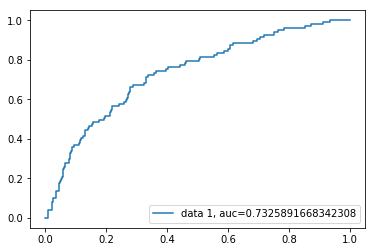

```python
y_pred_proba = logisticRegr.predict_proba(x_test)[::,1]
fpr, tpr, _ = metrics.roc_curve(y_test, y_pred_proba)
auc = metrics.roc_auc_score(y_test, y_pred_proba)
plt.plot(fpr,tpr,label="data 1, auc="+str(auc))
plt.legend(loc=4)
plt.show()
```

We still get a bad result (as our precision, recall, f1-score is at 0), but as we noted prior, this is due to an inbalanced class sample, so our model needs pre-processing via means of:

- Putting weights on errors proportional to the class imbalance.
- Re-sample the data to balance the positive/negatives classes.

#### With pre-processing data:

```python
## Method 1: Putting weights using skleaern's class_weight parameter

logisticRegr = LogisticRegression(solver='liblinear', random_state=10, class_weight='balanced')
logisticRegr.fit(x_train, y_train)
y_test_pred = logisticRegr.predict(x_test)
cnf_matrix = metrics.confusion_matrix(y_test, y_test_pred)
print(cnf_matrix)
print(metrics.classification_report(y_test, y_test_pred))
```

```
[[1298  599]
 [  34   63]]
              precision    recall  f1-score   support

       False       0.97      0.68      0.80      1897
        True       0.10      0.65      0.17        97

   micro avg       0.68      0.68      0.68      1994
   macro avg       0.53      0.67      0.48      1994
weighted avg       0.93      0.68      0.77      1994
```

Now, we can see some progress as there were 63 correctly predicted hit songs, but our precision and f1-score is relatively low at 0.10 and 0.17 respectively.

We can see the model's AUC like so:

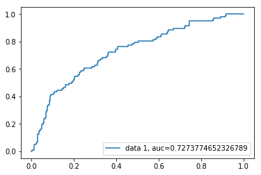

```python
y_pred_proba = logisticRegr.predict_proba(x_test)[::,1]
fpr, tpr, _ = metrics.roc_curve(y_test, y_pred_proba)
auc = metrics.roc_auc_score(y_test, y_pred_proba)
plt.plot(fpr,tpr,label="data 1, auc="+str(auc))
plt.legend(loc=4)
plt.show()
```

Another method of providing weights can be achieved doing a manual grid search with varying weights to see which weights correspond to the highest f1-score.

```
Best parameters : {'class_weight': {0: 0.09736842105263158, 1: 0.9026315789473685}}
```

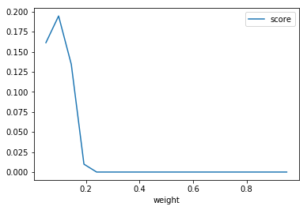

```python
weights = np.linspace(0.05, 0.95, 20)

gsc = GridSearchCV(
    estimator=LogisticRegression(solver='liblinear', random_state=10),
    param_grid={
        'class_weight': [{0: x, 1: 1.0-x} for x in weights]
    },
    scoring='f1',
    cv=3
)
grid_result = gsc.fit(x_train, y_train)

print("Best parameters : %s" % grid_result.best_params_)

# Plot the weights vs f1 score
dataz = pd.DataFrame({ 'score': grid_result.cv_results_['mean_test_score'],
                       'weight': weights })
dataz.plot(x='weight')
```

We get the best class weight parameters to be: 0.098 for class 0 and 0.903 for class 1

```python
## Method 2: Putting calculated weights using grid search

logisticRegr = LogisticRegression(solver='liblinear', random_state=10, **grid_result.best_params_)
logisticRegr.fit(x_train, y_train)
y_test_pred = logisticRegr.predict(x_test)
cnf_matrix = metrics.confusion_matrix(y_test, y_test_pred)
print(cnf_matrix)
print(metrics.classification_report(y_test, y_test_pred))
```

```
[[1772  125]
 [  71   26]]
              precision    recall  f1-score   support

       False       0.96      0.93      0.95      1897
        True       0.17      0.27      0.21        97

   micro avg       0.90      0.90      0.90      1994
   macro avg       0.57      0.60      0.58      1994
weighted avg       0.92      0.90      0.91      1994
```

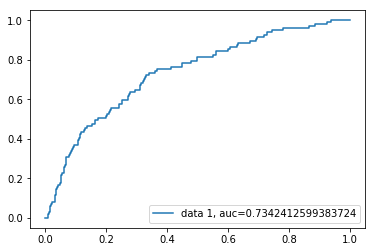

```python
y_pred_proba = logisticRegr.predict_proba(x_test)[::,1]
fpr, tpr, _ = metrics.roc_curve(y_test, y_pred_proba)
auc = metrics.roc_auc_score(y_test, y_pred_proba)
plt.plot(fpr,tpr,label="data 1, auc="+str(auc))
plt.legend(loc=4)
plt.show()
```

We do get a better model compared to sklearn's balanced class weight parameter as our precision score has now improved to 0.17, f1-score to 0.21, and AUC to 0.73.

Next, we can try a re-sampling technique known as SMOTE: Synthetic Minority Over-sampling Technique. SMOTE is a very common sampling technique that synthesises new minority instances between existing (real) minority instances.

```python
## Method 3: SMOTE

pipe = make_pipeline(
    SMOTE(),
    LogisticRegression(solver='liblinear', random_state=10)
)

# Fit..
pipe.fit(x_train, y_train)

# Predict..
y_pred = pipe.predict(x_test)

# Evaluate the model
cnf_matrix = metrics.confusion_matrix(y_test, y_pred)
print(cnf_matrix)
print(metrics.classification_report(y_test, y_pred))
```

```
[[1323  574]
 [  32   65]]
              precision    recall  f1-score   support

       False       0.98      0.70      0.81      1897
        True       0.10      0.67      0.18        97

   micro avg       0.70      0.70      0.70      1994
   macro avg       0.54      0.68      0.50      1994
weighted avg       0.93      0.70      0.78      1994
```

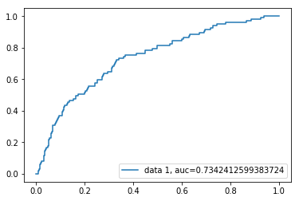

```python
y_pred_proba = logisticRegr.predict_proba(x_test)[::,1]
fpr, tpr, _ = metrics.roc_curve(y_test, y_pred_proba)
auc = metrics.roc_auc_score(y_test, y_pred_proba)
plt.plot(fpr,tpr,label="data 1, auc="+str(auc))
plt.legend(loc=4)
plt.show()
```

```
Best parameters : {'smote__sampling_strategy': 0.381578947368421}
```

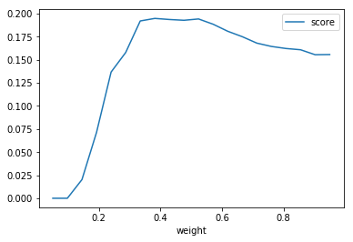

```python
pipe = make_pipeline(
    SMOTE(),
    LogisticRegression(solver='liblinear', random_state=10)
)

weights = np.linspace(0.05, 0.95, 20)

gsc = GridSearchCV(
    estimator=pipe,
    param_grid={
        "smote__sampling_strategy": [x for x in weights]
    },
    scoring='f1',
    cv=3
)
grid_result = gsc.fit(X, y)

print("Best parameters : %s" % grid_result.best_params_)

# Plot the weights vs f1 score
dataz = pd.DataFrame({ 'score': grid_result.cv_results_['mean_test_score'],
                       'weight': weights })
dataz.plot(x='weight')
```

```python
## Method 4: SMOTE + optimal ratio
pipe = make_pipeline(
    SMOTE(sampling_strategy=0.381578947368421),
    LogisticRegression(solver='liblinear', random_state=10)
)

# Fit..
pipe.fit(x_train, y_train)

# Predict..
y_pred = pipe.predict(x_test)

# Evaluate the model
cnf_matrix = metrics.confusion_matrix(y_test, y_pred)
print(cnf_matrix)
print(metrics.classification_report(y_test, y_pred))
```

```
[[1748  149]
 [  67   30]]
              precision    recall  f1-score   support

       False       0.96      0.92      0.94      1897
        True       0.17      0.31      0.22        97

   micro avg       0.89      0.89      0.89      1994
   macro avg       0.57      0.62      0.58      1994
weighted avg       0.92      0.89      0.91      1994
```

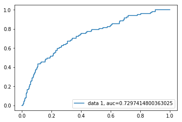

```python
y_pred_proba = pipe.predict_proba(x_test)[::,1]
fpr, tpr, _ = metrics.roc_curve(y_test, y_pred_proba)
auc = metrics.roc_auc_score(y_test, y_pred_proba)
plt.plot(fpr,tpr,label="data 1, auc="+str(auc))
plt.legend(loc=4)
plt.show()
```

At this point, all we can say is this is the extent our logistic model can improve in terms of performance. The precision is at 0.17 (highest so far) and f1-score at 0.22 (highest so far).

### Technique 2: Gaussian Naive Bayes

First, we separate the data indicating X as the independent variables, and y as the dependent variable.

```python
predictors = ["acousticness", "danceability", "energy", "instrumentalness", "liveness", "loudness", "speechiness", "tempo", "valence", "artist_popularity"]
X = df[predictors]
y = df["hit"].astype("bool")
```

#### Without pre-processing data:

```python
# Split training data and validating data (70-30 split)
x_train, x_test, y_train, y_test = train_test_split(X, y, test_size=0.3)
gnb = GaussianNB()
gnb.fit(x_train, y_train)
y_test_pred = gnb.predict(x_test)
cnf_matrix = metrics.confusion_matrix(y_test, y_test_pred)
print(cnf_matrix)
print(metrics.classification_report(y_test, y_test_pred))
```

```
[[1866   40]
 [  73   15]]
              precision    recall  f1-score   support

       False       0.96      0.98      0.97      1906
        True       0.27      0.17      0.21        88

   micro avg       0.94      0.94      0.94      1994
   macro avg       0.62      0.57      0.59      1994
weighted avg       0.93      0.94      0.94      1994
```

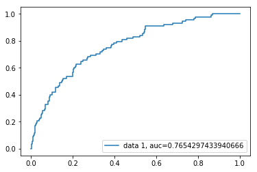

```python
y_pred_proba = gnb.predict_proba(x_test)[::,1]
fpr, tpr, _ = metrics.roc_curve(y_test, y_pred_proba)
auc = metrics.roc_auc_score(y_test, y_pred_proba)
plt.plot(fpr,tpr,label="data 1, auc="+str(auc))
plt.legend(loc=4)
plt.show()
```

Already, using Gaussian Naive Bayes, we get a comparable result to the pre-processed Logistic Model (albeit a lower recall score). The AUC is at 0.76 as well, the highest score we've achieved so far.

Next, we can implement the same pre-processing techniques we used before.

#### With pre-processing data:

```
Best parameters : {'priors': [0.9026315789473683, 0.09736842105263166]}
```

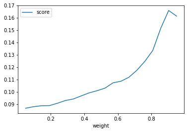

```python
# Method 1: Using optimal priors (Prior probabilities of the classes) with grid search

weights = np.linspace(0.05, 0.95, 20)

gsc = GridSearchCV(
    estimator=GaussianNB(),
    param_grid={
        'priors': [[x, 1.0-x] for x in weights]
    },
    scoring='f1',
    cv=3
)
grid_result = gsc.fit(x_train, y_train)

print("Best parameters : %s" % grid_result.best_params_)

# Plot the weights vs f1 score
dataz = pd.DataFrame({ 'score': grid_result.cv_results_['mean_test_score'],
                       'weight': weights })
dataz.plot(x='weight')
```

```python
gnb = GaussianNB(**grid_result.best_params_)
gnb.fit(x_train, y_train)
y_test_pred = gnb.predict(x_test)
cnf_matrix = metrics.confusion_matrix(y_test, y_test_pred)
print(cnf_matrix)
print(metrics.classification_report(y_test, y_test_pred))
```

```
[[1649  257]
 [  47   41]]
              precision    recall  f1-score   support

       False       0.97      0.87      0.92      1906
        True       0.14      0.47      0.21        88

   micro avg       0.85      0.85      0.85      1994
   macro avg       0.55      0.67      0.56      1994
weighted avg       0.94      0.85      0.88      1994
```

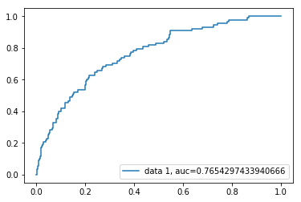

```python
y_pred_proba = gnb.predict_proba(x_test)[::,1]
fpr, tpr, _ = metrics.roc_curve(y_test, y_pred_proba)
auc = metrics.roc_auc_score(y_test, y_pred_proba)
plt.plot(fpr,tpr,label="data 1, auc="+str(auc))
plt.legend(loc=4)
plt.show()
```

Precision scored dropped to 0.14, albeit increasing our recall score. F1 remains the same, hovering around .2. The AUC remains at 0.76 as well.

Now, if we do the SMOTE method with optimal priors:

```
Best parameters : {'smote__sampling_strategy': 0.05}
```

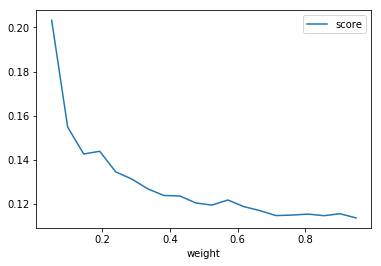

```python
## Method 2: SMOTE + optimal ratio
pipe = make_pipeline(
    SMOTE(),
    GaussianNB()
)

weights = np.linspace(0.05, 0.95, 20)

gsc = GridSearchCV(
    estimator=pipe,
    param_grid={
        "smote__sampling_strategy": [x for x in weights]
    },
    scoring='f1',
    cv=3
)
grid_result = gsc.fit(X, y)

print("Best parameters : %s" % grid_result.best_params_)

# Plot the weights vs f1 score
dataz = pd.DataFrame({ 'score': grid_result.cv_results_['mean_test_score'],
                       'weight': weights })
dataz.plot(x='weight')
```

```python
pipe = make_pipeline(
    SMOTE(sampling_strategy=0.05),
    GaussianNB()
)

# Fit..
pipe.fit(x_train, y_train)

# Predict..
y_pred = pipe.predict(x_test)

# Evaluate the model
cnf_matrix = metrics.confusion_matrix(y_test, y_pred)
print(cnf_matrix)
print(metrics.classification_report(y_test, y_pred))
```

```
[[1877   29]
 [  78   10]]
              precision    recall  f1-score   support

       False       0.96      0.98      0.97      1906
        True       0.26      0.11      0.16        88

   micro avg       0.95      0.95      0.95      1994
   macro avg       0.61      0.55      0.56      1994
weighted avg       0.93      0.95      0.94      1994
```

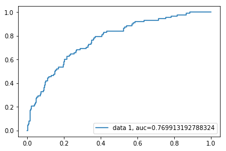

```python
y_pred_proba = pipe.predict_proba(x_test)[::,1]
fpr, tpr, _ = metrics.roc_curve(y_test, y_pred_proba)
auc = metrics.roc_auc_score(y_test, y_pred_proba)
plt.plot(fpr,tpr,label="data 1, auc="+str(auc))
plt.legend(loc=4)
plt.show()
```

The SMOTE method provided minimal inprovement in precision, but lower recall and f1-scores.

### Technique 3: Decision Trees

First, we separate the data indicating X as the independent variables, and y as the dependent variable.

```python
predictors = ["acousticness", "danceability", "energy", "instrumentalness", "liveness", "loudness", "speechiness", "tempo", "valence", "artist_popularity"]
X = df[predictors]
y = df["hit"].astype("bool")
```

#### Without pre-processing data:

```python
x_train, x_test, y_train, y_test = train_test_split(X, y, test_size=0.3)
decTree = DecisionTreeClassifier(random_state = 10)
decTree.fit(x_train, y_train)
y_test_pred = decTree.predict(x_test)
cnf_matrix = metrics.confusion_matrix(y_test, y_test_pred)
print(cnf_matrix)
print(metrics.classification_report(y_test, y_test_pred))
```

```
[[1806   98]
 [  71   19]]
              precision    recall  f1-score   support

       False       0.96      0.95      0.96      1904
        True       0.16      0.21      0.18        90

   micro avg       0.92      0.92      0.92      1994
   macro avg       0.56      0.58      0.57      1994
weighted avg       0.93      0.92      0.92      1994
```

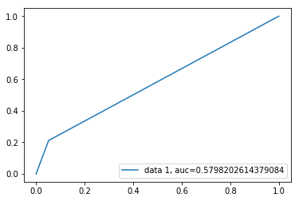

```python
y_pred_proba = decTree.predict_proba(x_test)[::,1]
fpr, tpr, _ = metrics.roc_curve(y_test, y_pred_proba)
auc = metrics.roc_auc_score(y_test, y_pred_proba)
plt.plot(fpr,tpr,label="data 1, auc="+str(auc))
plt.legend(loc=4)
plt.show()
```

Using Decision Trees, we get a very similar results to the two other models we used before (Naive Gaussian Bayes and Logistic Regression). However, notice that our AUC score is at its lowest (0.579)

Next, we can implement the same pre-processing techniques we used before.

#### With pre-processing data:

Using decision tress, we can attempt to further improve our model by actually selecting features that provides good impurity reduction (The measure based on which the (locally) optimal condition is chosen is called impurity).

Thus when training a tree, it can be computed how much each feature decreases the weighted impurity in a tree. For a forest, the impurity decrease from each feature can be averaged and the features are ranked according to this measure.

For sklearn's decision trees, our impurity measure is defaulted to Gini impurity.

```python
feature_imp = pd.Series(decTree.feature_importances_,index=predictors).sort_values(ascending=False)
feature_imp
```

```
loudness             0.143632
acousticness         0.137652
tempo                0.129540
danceability         0.119468
liveness             0.117228
speechiness          0.082234
energy               0.077908
artist_popularity    0.077029
valence              0.072830
instrumentalness     0.042480
dtype: float64
```

```python
predictors = ["acousticness", "danceability", "energy", "liveness", "loudness", "speechiness", "tempo", "valence", "artist_popularity"]
X = df[predictors]
y = df["hit"].astype("bool")
```

```python
x_train, x_test, y_train, y_test = train_test_split(X, y, test_size=0.3)
decTree = DecisionTreeClassifier(random_state = 10)
decTree.fit(x_train, y_train)
y_test_pred = decTree.predict(x_test)
cnf_matrix = metrics.confusion_matrix(y_test, y_test_pred)
print(cnf_matrix)
print(metrics.classification_report(y_test, y_test_pred))
```

```
[[1820   89]
 [  64   21]]
              precision    recall  f1-score   support

       False       0.97      0.95      0.96      1909
        True       0.19      0.25      0.22        85

   micro avg       0.92      0.92      0.92      1994
   macro avg       0.58      0.60      0.59      1994
weighted avg       0.93      0.92      0.93      1994
```

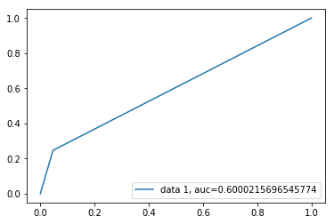

```python
y_pred_proba = decTree.predict_proba(x_test)[::,1]
fpr, tpr, _ = metrics.roc_curve(y_test, y_pred_proba)
auc = metrics.roc_auc_score(y_test, y_pred_proba)
plt.plot(fpr,tpr,label="data 1, auc="+str(auc))
plt.legend(loc=4)
plt.show()
```

We get a small but slight improvement from the feature reduction.

```python
## Method 1: Putting weights using skleaern's class_weight parameter

decTree = DecisionTreeClassifier(random_state=10, class_weight='balanced')
decTree.fit(x_train, y_train)
y_test_pred = decTree.predict(x_test)
cnf_matrix = metrics.confusion_matrix(y_test, y_test_pred)
print(cnf_matrix)
print(metrics.classification_report(y_test, y_test_pred))
```

```
[[1833   76]
 [  62   23]]
              precision    recall  f1-score   support

       False       0.97      0.96      0.96      1909
        True       0.23      0.27      0.25        85

   micro avg       0.93      0.93      0.93      1994
   macro avg       0.60      0.62      0.61      1994
weighted avg       0.94      0.93      0.93      1994
```

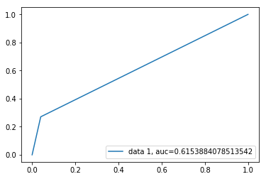

```python
y_pred_proba = decTree.predict_proba(x_test)[::,1]
fpr, tpr, _ = metrics.roc_curve(y_test, y_pred_proba)
auc = metrics.roc_auc_score(y_test, y_pred_proba)
plt.plot(fpr,tpr,label="data 1, auc="+str(auc))
plt.legend(loc=4)
plt.show()
```

Using sklearn's class weight parameter, we get an even higher f1-score at 0.25. Our AUC score has also slightly increased to (0.615)

```
Best parameters : {'class_weight': {0: 0.23947368421052628, 1: 0.7605263157894737}}
```

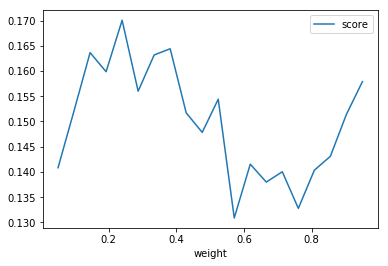

```python
weights = np.linspace(0.05, 0.95, 20)

gsc = GridSearchCV(
    estimator=DecisionTreeClassifier(random_state=10),
    param_grid={
        'class_weight': [{0: x, 1: 1.0-x} for x in weights]
    },
    scoring='f1',
    cv=3
)
grid_result = gsc.fit(x_train, y_train)

print("Best parameters : %s" % grid_result.best_params_)

# Plot the weights vs f1 score
dataz = pd.DataFrame({ 'score': grid_result.cv_results_['mean_test_score'],
                       'weight': weights })
dataz.plot(x='weight')
```

```python
## Method 2: Putting calculated weights using grid search

decTree = DecisionTreeClassifier(random_state=10, **grid_result.best_params_)
decTree.fit(x_train, y_train)
y_test_pred = decTree.predict(x_test)
cnf_matrix = metrics.confusion_matrix(y_test, y_test_pred)
print(cnf_matrix)
print(metrics.classification_report(y_test, y_test_pred))
```

```
[[1826   83]
 [  68   17]]
              precision    recall  f1-score   support

       False       0.96      0.96      0.96      1909
        True       0.17      0.20      0.18        85

   micro avg       0.92      0.92      0.92      1994
   macro avg       0.57      0.58      0.57      1994
weighted avg       0.93      0.92      0.93      1994
```

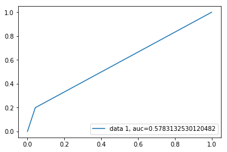

```python
y_pred_proba = decTree.predict_proba(x_test)[::,1]
fpr, tpr, _ = metrics.roc_curve(y_test, y_pred_proba)
auc = metrics.roc_auc_score(y_test, y_pred_proba)
plt.plot(fpr,tpr,label="data 1, auc="+str(auc))
plt.legend(loc=4)
plt.show()
```

We pretty much get a similar result as Method 1 (might even be worse).

```python
## Method 3: SMOTE

pipe = make_pipeline(
    SMOTE(),
    DecisionTreeClassifier(random_state=10)
)

# Fit..
pipe.fit(x_train, y_train)

# Predict..
y_pred = pipe.predict(x_test)

# Evaluate the model
cnf_matrix = metrics.confusion_matrix(y_test, y_pred)
print(cnf_matrix)
print(metrics.classification_report(y_test, y_pred))
```

```
[[1690  219]
 [  54   31]]
              precision    recall  f1-score   support

       False       0.97      0.89      0.93      1909
        True       0.12      0.36      0.19        85

   micro avg       0.86      0.86      0.86      1994
   macro avg       0.55      0.62      0.56      1994
weighted avg       0.93      0.86      0.89      1994
```

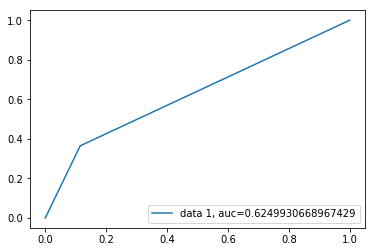

```python
y_pred_proba = pipe.predict_proba(x_test)[::,1]
fpr, tpr, _ = metrics.roc_curve(y_test, y_pred_proba)
auc = metrics.roc_auc_score(y_test, y_pred_proba)
plt.plot(fpr,tpr,label="data 1, auc="+str(auc))
plt.legend(loc=4)
plt.show()
```

Using the SMOTE method, we get a higher AUC score (0.62) and seems to have a higher recall score. But our precision rate has taken a hit (0.12).

```
Best parameters : {'smote__sampling_strategy': 0.19210526315789472}
```

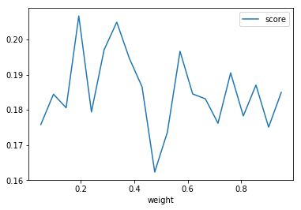

```python
## Method 4: SMOTE + optimal ratio

pipe = make_pipeline(
    SMOTE(),
    DecisionTreeClassifier(random_state=10)
)

weights = np.linspace(0.05, 0.95, 20)

gsc = GridSearchCV(
    estimator=pipe,
    param_grid={
        "smote__sampling_strategy": [x for x in weights]
    },
    scoring='f1',
    cv=3
)
grid_result = gsc.fit(X, y)

print("Best parameters : %s" % grid_result.best_params_)

# Plot the weights vs f1 score
dataz = pd.DataFrame({ 'score': grid_result.cv_results_['mean_test_score'],
                       'weight': weights })
dataz.plot(x='weight')
```

```python
pipe = make_pipeline(
    SMOTE(sampling_strategy=0.19210526315789472),
    DecisionTreeClassifier(random_state=10)
)

# Fit..
pipe.fit(x_train, y_train)

# Predict..
y_pred = pipe.predict(x_test)

# Evaluate the model
cnf_matrix = metrics.confusion_matrix(y_test, y_pred)
print(cnf_matrix)
print(metrics.classification_report(y_test, y_pred))
```

```
[[1766  143]
 [  60   25]]
              precision    recall  f1-score   support

       False       0.97      0.93      0.95      1909
        True       0.15      0.29      0.20        85

   micro avg       0.90      0.90      0.90      1994
   macro avg       0.56      0.61      0.57      1994
weighted avg       0.93      0.90      0.91      1994
```

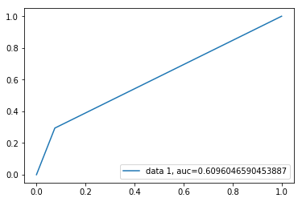

```python
y_pred_proba = pipe.predict_proba(x_test)[::,1]
fpr, tpr, _ = metrics.roc_curve(y_test, y_pred_proba)
auc = metrics.roc_auc_score(y_test, y_pred_proba)
plt.plot(fpr,tpr,label="data 1, auc="+str(auc))
plt.legend(loc=4)
plt.show()
```

Method 4 provdies us a model that is very similar to all the pre-processed Decision Tree models.

### Technique 4: Random Forests

First, we separate the data indicating X as the independent variables, and y as the dependent variable.

```python
predictors = ["acousticness", "danceability", "energy", "instrumentalness", "liveness", "loudness", "speechiness", "tempo", "valence", "artist_popularity"]
X = df[predictors]
y = df["hit"].astype("bool")
```

#### Without pre-processing:

```python
x_train, x_test, y_train, y_test = train_test_split(X, y, test_size=0.3)

rfTree=RandomForestClassifier(n_estimators=100, random_state=20)
rfTree.fit(x_train, y_train)
y_pred = rfTree.predict(x_test)
cnf_matrix = metrics.confusion_matrix(y_test, y_pred)
print(cnf_matrix)
print(metrics.classification_report(y_test, y_pred))
```

```
[[1913    2]
 [  69   10]]
              precision    recall  f1-score   support

       False       0.97      1.00      0.98      1915
        True       0.83      0.13      0.22        79

   micro avg       0.96      0.96      0.96      1994
   macro avg       0.90      0.56      0.60      1994
weighted avg       0.96      0.96      0.95      1994
```

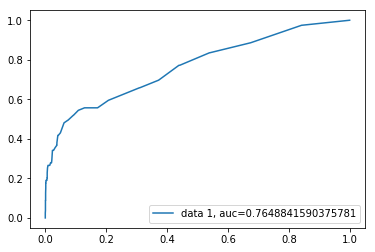

```python
y_pred_proba = rfTree.predict_proba(x_test)[::,1]
fpr, tpr, _ = metrics.roc_curve(y_test, y_pred_proba)
auc = metrics.roc_auc_score(y_test, y_pred_proba)
plt.plot(fpr,tpr,label="data 1, auc="+str(auc))
plt.legend(loc=4)
plt.show()
```

Now we're getting somewhere! We see that our precision sore has increased vastly to 0.83, albeit our low recall score and f1-score.

The AUC is at 0.764 which signals a good indicator that our model performs well.

#### With pre-processing:

Very similar to decision trees, we can conduct feature reduction using the same method based on impurity scores.

In fact Random forest is simply of a number of decision trees (in our case 100 trees). Every node in the decision trees is a conditional on a single feature, designed to split the dataset into two so that similar response values end up in the same set.

For sklearn's random forests, our impurity measure is defaulted to Gini impurity.

```python
feature_imp = pd.Series(rfTree.feature_importances_,index=predictors).sort_values(ascending=False)
feature_imp
```

```
tempo                0.118183
danceability         0.109975
speechiness          0.109001
artist_popularity    0.107442
loudness             0.105766
liveness             0.101695
acousticness         0.100775
energy               0.097329
valence              0.093922
instrumentalness     0.055913
dtype: float64
```

Here, we see that instrumentalness again has the lowest score, thus we can remove it and train our model again.

```python
predictors = ["acousticness", "danceability", "energy", "liveness", "loudness", "speechiness", "tempo", "valence", "artist_popularity"]
X = df[predictors]
y = df["hit"].astype("bool")
```

```python
x_train, x_test, y_train, y_test = train_test_split(X, y, test_size=0.3)

rfTree=RandomForestClassifier(n_estimators=100, random_state=20)
rfTree.fit(x_train, y_train)
y_pred = rfTree.predict(x_test)
cnf_matrix = metrics.confusion_matrix(y_test, y_pred)
print(cnf_matrix)
print(metrics.classification_report(y_test, y_pred))
```

```
[[1916    0]
 [  69    9]]
              precision    recall  f1-score   support

       False       0.97      1.00      0.98      1916
        True       1.00      0.12      0.21        78

   micro avg       0.97      0.97      0.97      1994
   macro avg       0.98      0.56      0.59      1994
weighted avg       0.97      0.97      0.95      1994
```

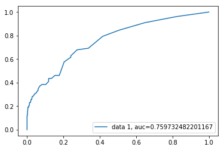

```python
y_pred_proba = rfTree.predict_proba(x_test)[::,1]
fpr, tpr, _ = metrics.roc_curve(y_test, y_pred_proba)
auc = metrics.roc_auc_score(y_test, y_pred_proba)
plt.plot(fpr,tpr,label="data 1, auc="+str(auc))
plt.legend(loc=4)
plt.show()
```

Removing instrumentalness as a predictor, gave us a precision score of 1.00! The AUC score remains the same at 0.759.

Next, we can attempt to provide weights and re-sample using SMOTE.

```python
## Method 1: Putting weights using skleaern's class_weight parameter

rfTree=RandomForestClassifier(n_estimators=100, random_state=20, class_weight="balanced")
rfTree.fit(x_train, y_train)
y_pred = rfTree.predict(x_test)
cnf_matrix = metrics.confusion_matrix(y_test, y_pred)
print(cnf_matrix)
print(metrics.classification_report(y_test, y_pred))
```

```
[[1916    0]
 [  70    8]]
              precision    recall  f1-score   support

       False       0.96      1.00      0.98      1916
        True       1.00      0.10      0.19        78

   micro avg       0.96      0.96      0.96      1994
   macro avg       0.98      0.55      0.58      1994
weighted avg       0.97      0.96      0.95      1994
```

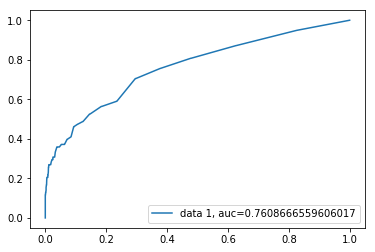

```python
y_pred_proba = rfTree.predict_proba(x_test)[::,1]
fpr, tpr, _ = metrics.roc_curve(y_test, y_pred_proba)
auc = metrics.roc_auc_score(y_test, y_pred_proba)
plt.plot(fpr,tpr,label="data 1, auc="+str(auc))
plt.legend(loc=4)
plt.show()
```

Very similar results, with precision score at 1.0 again. The AUC has marginally improved to 0.76.

```
Best parameters : {'class_weight': {0: 0.7131578947368421, 1: 0.2868421052631579}}
```

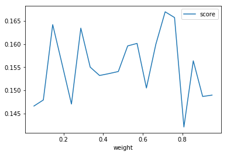

```python
weights = np.linspace(0.05, 0.95, 20)

gsc = GridSearchCV(
    estimator=RandomForestClassifier(n_estimators=100, random_state=20),
    param_grid={
        'class_weight': [{0: x, 1: 1.0-x} for x in weights]
    },
    scoring='f1',
    cv=3
)
grid_result = gsc.fit(x_train, y_train)

print("Best parameters : %s" % grid_result.best_params_)

# Plot the weights vs f1 score
dataz = pd.DataFrame({ 'score': grid_result.cv_results_['mean_test_score'],
                       'weight': weights })
dataz.plot(x='weight')
```

```python
## Method 2: Putting calculated weights using grid search

rfTree=RandomForestClassifier(n_estimators=100, random_state=20, **grid_result.best_params_)
rfTree.fit(x_train, y_train)
y_pred = rfTree.predict(x_test)
cnf_matrix = metrics.confusion_matrix(y_test, y_pred)
print(cnf_matrix)
print(metrics.classification_report(y_test, y_pred))
```

```
[[1914    2]
 [  70    8]]
              precision    recall  f1-score   support

       False       0.96      1.00      0.98      1916
        True       0.80      0.10      0.18        78

   micro avg       0.96      0.96      0.96      1994
   macro avg       0.88      0.55      0.58      1994
weighted avg       0.96      0.96      0.95      1994
```

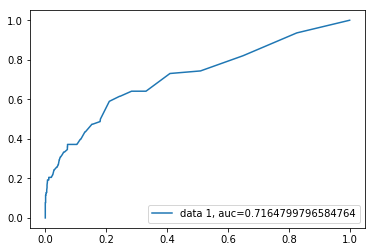

```python
y_pred_proba = rfTree.predict_proba(x_test)[::,1]
fpr, tpr, _ = metrics.roc_curve(y_test, y_pred_proba)
auc = metrics.roc_auc_score(y_test, y_pred_proba)
plt.plot(fpr,tpr,label="data 1, auc="+str(auc))
plt.legend(loc=4)
plt.show()
```

Method 2 did not provide an improvement and performed worse than Method 1.

```python
## Method 3: SMOTE

pipe = make_pipeline(
    SMOTE(),
    RandomForestClassifier(n_estimators=100, random_state=20)
)

# Fit..
pipe.fit(x_train, y_train)

# Predict..
y_pred = pipe.predict(x_test)

# Evaluate the model
cnf_matrix = metrics.confusion_matrix(y_test, y_pred)
print(cnf_matrix)
print(metrics.classification_report(y_test, y_pred))
```

```
[[1813  103]
 [  56   22]]
              precision    recall  f1-score   support

       False       0.97      0.95      0.96      1916
        True       0.18      0.28      0.22        78

   micro avg       0.92      0.92      0.92      1994
   macro avg       0.57      0.61      0.59      1994
weighted avg       0.94      0.92      0.93      1994
```

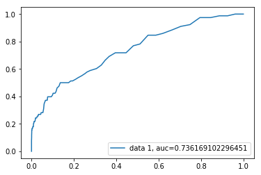

```python
y_pred_proba = pipe.predict_proba(x_test)[::,1]
fpr, tpr, _ = metrics.roc_curve(y_test, y_pred_proba)
auc = metrics.roc_auc_score(y_test, y_pred_proba)
plt.plot(fpr,tpr,label="data 1, auc="+str(auc))
plt.legend(loc=4)
plt.show()
```

Using the SMOTE method, we seem to get results similar to our previous ML techniques.

```
Best parameters : {'smote__sampling_strategy': 0.14473684210526316}
```

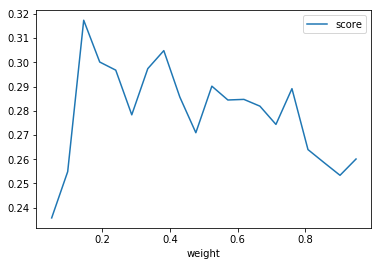

```python
## Method 4: SMOTE + optimal ratio

pipe = make_pipeline(
    SMOTE(),
    RandomForestClassifier(n_estimators=100, random_state=20)
)

weights = np.linspace(0.05, 0.95, 20)

gsc = GridSearchCV(
    estimator=pipe,
    param_grid={
        "smote__sampling_strategy": [x for x in weights]
    },
    scoring='f1',
    cv=3
)
grid_result = gsc.fit(X, y)

print("Best parameters : %s" % grid_result.best_params_)

# Plot the weights vs f1 score
dataz = pd.DataFrame({ 'score': grid_result.cv_results_['mean_test_score'],
                       'weight': weights })
dataz.plot(x='weight')
```

```python
pipe = make_pipeline(
    SMOTE(sampling_strategy=0.14473684210526316),
    RandomForestClassifier(n_estimators=100, random_state=20)
)

# Fit..
pipe.fit(x_train, y_train)

# Predict..
y_pred = pipe.predict(x_test)

# Evaluate the model
cnf_matrix = metrics.confusion_matrix(y_test, y_pred)
print(cnf_matrix)
print(metrics.classification_report(y_test, y_pred))
```

```
[[1905   11]
 [  64   14]]
              precision    recall  f1-score   support

       False       0.97      0.99      0.98      1916
        True       0.56      0.18      0.27        78

   micro avg       0.96      0.96      0.96      1994
   macro avg       0.76      0.59      0.63      1994
weighted avg       0.95      0.96      0.95      1994
```

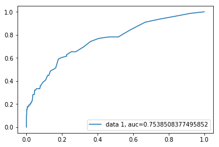

```python
y_pred_proba = pipe.predict_proba(x_test)[::,1]
fpr, tpr, _ = metrics.roc_curve(y_test, y_pred_proba)
auc = metrics.roc_auc_score(y_test, y_pred_proba)
plt.plot(fpr,tpr,label="data 1, auc="+str(auc))
plt.legend(loc=4)
plt.show()
```

Method 4 did provide better results than Method 3.

# Model Summary (Evaluations)

| Method | Precision | Recall | F1-Score | AUC |
| --- | --- | --- | --- | --- |
| Logistic Regression (NO pre-processing) | 0 | 0 | 0 | 0.732 |
| Logistic Regression (Balanced Class Weights) | 0.1 | 0.65 | 0.17 | 0.727 |
| Logistic Regression (Calculated Weights) | 0.17 | 0.27 | 0.21 | 0.734 |
| Logistic Regression (SMOTE) | 0.1 | 0.67 | 0.18 | 0.734 |
| Logistic Regression (SMOTE + optimal ratio) | 0.17 | 0.31 | 0.22 | 0.729 |
| Gaussian Naive Bayes (NO pre-processing) | 0.27 | 0.17 | 0.21 | 0.765 |
| Gaussian Naive Bayes (Calculated Priors) | 0.14 | 0.47 | 0.21 | 0.765 |
| Gaussian Naive Bayes (SMOTE + optimal ratio) | 0.26 | 0.11 | 0.16 | 0.769 |
| Decision Trees (No pre-processing) | 0.16 | 0.21 | 0.18 | 0.579 |
| Decision Trees (After feature-reduction) | 0.19 | 0.25 | 0.22 | 0.600 |
| Decision Trees (Balanced Class Weights) | 0.23 | 0.27 | 0.25 | 0.615 |
| Decision Trees (Calculated Weights) | 0.17 | 0.2 | 0.18 | 0.578 |
| Decision Trees (SMOTE) | 0.12 | 0.36 | 0.19 | 0.625 |
| Decision Trees (SMOTE + optimal ratio) | 0.15 | 0.29 | 0.20 | 0.609 |
| Random Forests (No pre-processing) | 0.83 | 0.13 | 0.22 | 0.764 |
| Random Forests (After feature-reduction) | 1.00 | 0.12 | 0.21 | 0.759 |
| Random Forests (Balanced Class Weights) | 1.00 | 0.10 | 0.19 | 0.761 |
| Random Forests (Calculated Weights) | 0.80 | 0.10 | 0.18 | 0.716 |
| Random Forests (SMOTE) | 0.18 | 0.28 | 0.22 | 0.736 |
| Random Forests (SMOTE + optimal ratio) | 0.56 | 0.18 | 0.27 | 0.754 |

Above, we've compiled all the models' performance results in predicing hit songs.

For logistic regression, it seems like the pre-processed methods yielded better performance (albeit all similar) compared to the un-preprocessed method.

For Gaussian Naive Bayes, it seems like we weren't able to improve the benchmark set by the un-preprocessed method. Although, the calculated priors did yield a better recall score, it performed worsed in terms in precision. The SMOTE + optimal ration method did objectively worse amongst its Gaussian Naive Bayes counterparts.

For Decision Trees, it seems like this technique was the weakest amongst all the techiques we tried. However, we were able to beat the benchmark performance set by the un-preprocssed Decision Tree method after balancing the class weights.

For Random Forests, this technique overall performed the best amongst all the techinques we tried. We were able to marginally match the benchmark set by the un-preprocessed method with both feature-reduction and balanced class weights.

If we run the un-preprocessed Random Forest model, the feature-reduceed Random Forest model, and the balanced class weights Random Forest model on the entire data set we get the following:

```python
# Un-preprocessed
predictors = ["acousticness", "danceability", "energy", "instrumentalness", "liveness", "loudness", "speechiness", "tempo", "valence", "artist_popularity"]
X = df[predictors]
y = df["hit"].astype("bool")

x_train, x_test, y_train, y_test = train_test_split(X, y, test_size=0.3)

rfTree=RandomForestClassifier(n_estimators=100, random_state=20)
rfTree.fit(x_train, y_train)
y_pred = rfTree.predict(X)
cnf_matrix = metrics.confusion_matrix(y, y_pred)
print(cnf_matrix)
print(metrics.classification_report(y, y_pred))
```

```
[[6356    2]
 [  91  196]]
              precision    recall  f1-score   support

       False       0.99      1.00      0.99      6358
        True       0.99      0.68      0.81       287

   micro avg       0.99      0.99      0.99      6645
   macro avg       0.99      0.84      0.90      6645
weighted avg       0.99      0.99      0.98      6645
```

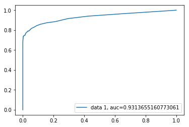

```python
y_pred_proba = rfTree.predict_proba(X)[::,1]
fpr, tpr, _ = metrics.roc_curve(y, y_pred_proba)
auc = metrics.roc_auc_score(y, y_pred_proba)
plt.plot(fpr,tpr,label="data 1, auc="+str(auc))
plt.legend(loc=4)
plt.show()
```

We get 196 songs that we predicted correctly, with precision score of 0.99, recall of 0.68, f1-score of 0.81, and AUC of 0.931.

```python
# Feature-reduced

predictors = ["acousticness", "danceability", "energy", "liveness", "loudness", "speechiness", "tempo", "valence", "artist_popularity"]
X = df[predictors]
y = df["hit"].astype("bool")

x_train, x_test, y_train, y_test = train_test_split(X, y, test_size=0.3)

rfTree=RandomForestClassifier(n_estimators=100, random_state=20)
rfTree.fit(x_train, y_train)
y_pred = rfTree.predict(X)
cnf_matrix = metrics.confusion_matrix(y, y_pred)
print(cnf_matrix)
print(metrics.classification_report(y, y_pred))
```

```
[[6355    3]
 [  77  210]]
              precision    recall  f1-score   support

       False       0.99      1.00      0.99      6358
        True       0.99      0.73      0.84       287

   micro avg       0.99      0.99      0.99      6645
   macro avg       0.99      0.87      0.92      6645
weighted avg       0.99      0.99      0.99      6645
```

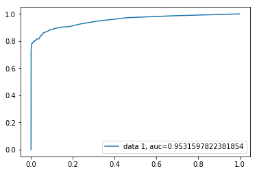

```python
y_pred_proba = rfTree.predict_proba(X)[::,1]
fpr, tpr, _ = metrics.roc_curve(y, y_pred_proba)
auc = metrics.roc_auc_score(y, y_pred_proba)
plt.plot(fpr,tpr,label="data 1, auc="+str(auc))
plt.legend(loc=4)
plt.show()
```

We get 210 songs that we predicted correctly, with precision score of 0.99, recall of 0.73, f1-score of 0.84, and AUC of 0.953.

```python
rfTree=RandomForestClassifier(n_estimators=100, random_state=20, class_weight="balanced")
rfTree.fit(x_train, y_train)
y_pred = rfTree.predict(X)
cnf_matrix = metrics.confusion_matrix(y, y_pred)
print(cnf_matrix)
print(metrics.classification_report(y, y_pred))
```

```
[[6352    6]
 [  73  214]]
              precision    recall  f1-score   support

       False       0.99      1.00      0.99      6358
        True       0.97      0.75      0.84       287

   micro avg       0.99      0.99      0.99      6645
   macro avg       0.98      0.87      0.92      6645
weighted avg       0.99      0.99      0.99      6645
```

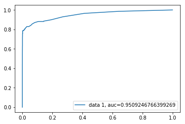

```python
y_pred_proba = rfTree.predict_proba(X)[::,1]
fpr, tpr, _ = metrics.roc_curve(y, y_pred_proba)
auc = metrics.roc_auc_score(y, y_pred_proba)
plt.plot(fpr,tpr,label="data 1, auc="+str(auc))
plt.legend(loc=4)
plt.show()
```

We get 214 songs that we predicted correctly, with precision score of 0.97, recall of 0.75, f1-score of 0.84, and AUC of 0.951.

Here are the compiled results:

| Method | Precision | Recall | F1-Score | AUC |
| --- | --- | --- | --- | --- |
| Random Forests (Un-preprocessed) | 0.99 | 0.68 | 0.81 | 0.931 |
| Random Forests (After feature reduction) | 0.99 | 0.73 | 0.84 | 0.953 |
| Random Forests (Balanced Class Weights) | 0.97 | 0.75 | 0.84 | 0.951 |

Overall, the two pre-processed methods did beat the beat the benchmark set by the un-preprocessed method with higher recall scores!

For curiosity, here are all the songs that the two pre-processed method predicted to be hits:

```python
print(data.loc[(data.RF1_pred) & (data.RF2_pred), ["track", "artist"]].to_string())
```

```
                                           track                      artist
2             Everybody Dies In Their Nightmares                XXXTENTACION
8                             Young Dumb & Broke                      Khalid
9                                        HUMBLE.              Kendrick Lamar
17                                  Let You Down                          NF
18                                      Location                      Khalid
22                                       Silence                  Marshmello
27                                       Perfect                  Ed Sheeran
31                                   Look At Me!                XXXTENTACION
34                  Drowning (feat. Kodak Black)      A Boogie Wit da Hoodie
38                                          DNA.              Kendrick Lamar
41                                    Plain Jane                   A$AP Ferg
43                          Too Good At Goodbyes                   Sam Smith
47              Love Galore (feat. Travis Scott)                         SZA
48                                 Losin Control                        Russ
```

[output cut: 197 more lines]